# Data Analysis System for Physicians Completing PANSS Testing and the Effect Language Has on the Score

Febuary 28th 2018

## Data Collection Protocol

## Shiny App

http://grahamst.at/shiny-server/PANSS/Input_App/

## Data Analysis

## Data Analysis System

http://grahamst.at/shiny-server/PANSS/Results_App/

## Data Cleaning

Data Entry Errors

| RATER | LANG | P3 | P7 | N2 | N7 |
| --- | --- | --- | --- | --- | --- |
| 10 | English | 8 | 2 | 5 | 1 |
| 32 | French | 5 | 2 | 4 | . |
| 40 | Italian | 2 | 9 | 5 | 3 |
| 62 | Italian | 6 | 1 | 0 | 2 |

## Physician's Passing Score

Number of Passes

| Language | Passed P | Passed N | Passed G | Passed | Total Physicians |
| --- | --- | --- | --- | --- | --- |
| English | 46 | 41 | 40 | 34 | 48 |
| French | 11 | 10 | 13 | 10 | 13 |
| Italian | 7 | 6 | 7 | 3 | 10 |

Mean Number of Questions Passed

| Language | P | N | G |
| --- | --- | --- | --- |
| English | 6.1250 | 5.5833 | 11.4792 |
| French | 5.6923 | 5.4615 | 11.9231 |
| Italian | 5.7000 | 5.3000 | 10.4000 |

## Effect of Language on Passing Score

### Positive Questions

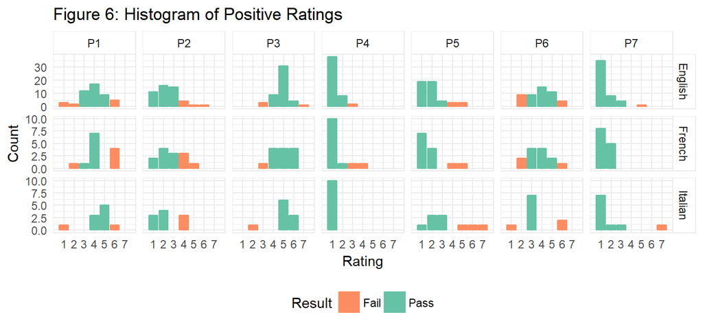

## Effect of Language on Passing Score

### Negative Questions

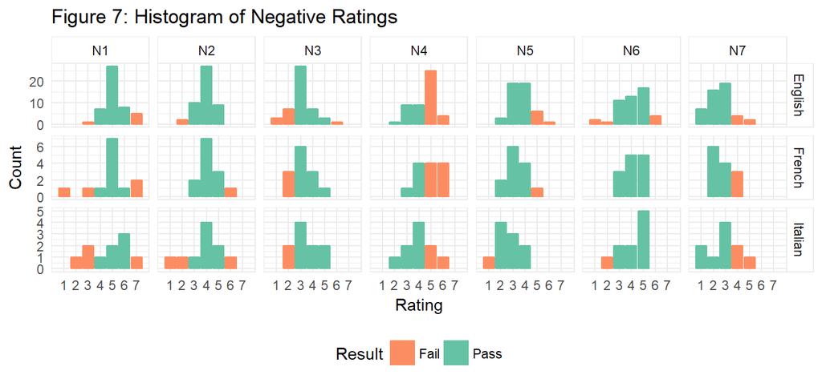

## Effect of Language on Passing Score

### Generic Questions (G01-G08)

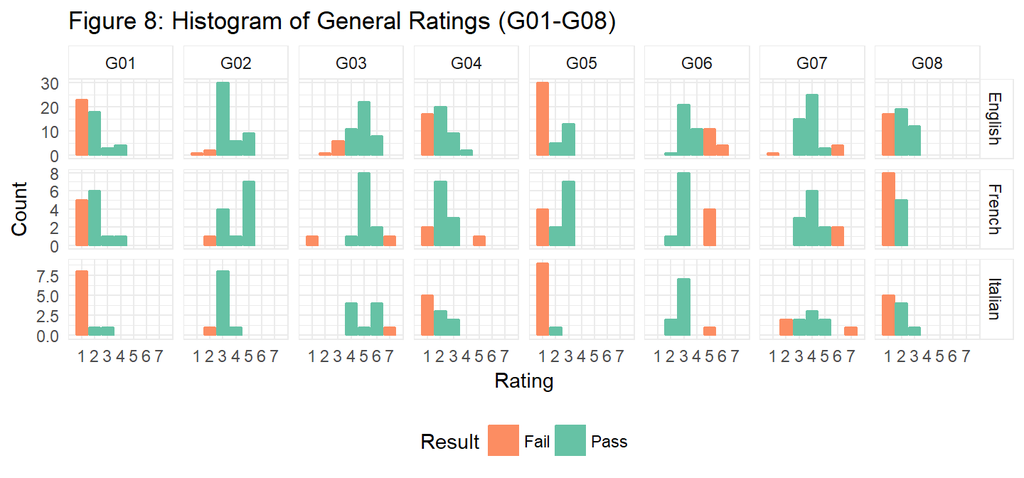

## Effect of Language on Passing Score

### Generic Questions (G09-G16)

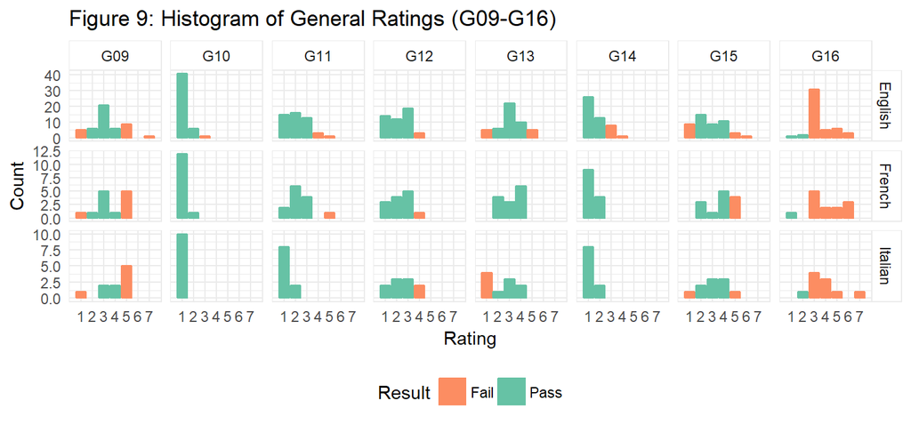

## Proportions of Raters who Passed by Language

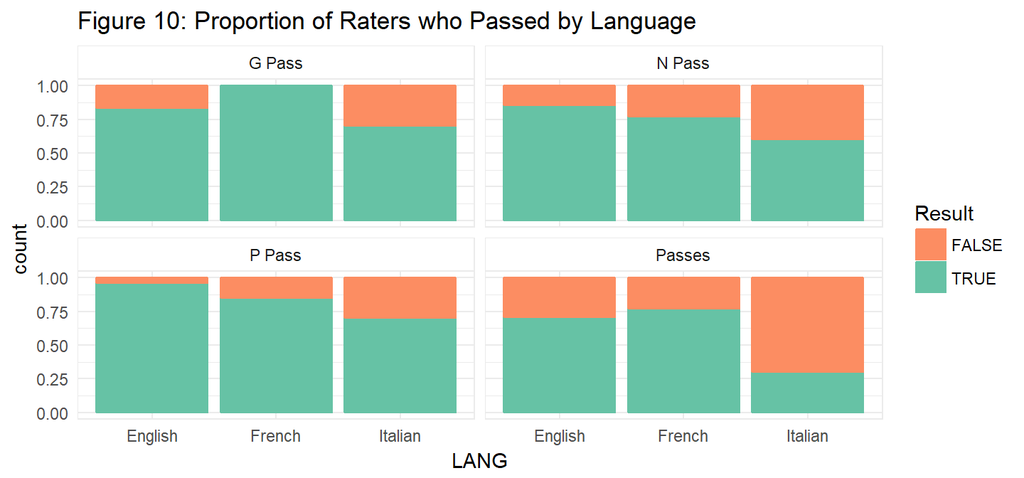

## Regression Analysis

### Positive Question Regression

Passes Question Set P by Language

|  | Estimate | Std. Error | z value | Pr(>\|z\|) |
| --- | --- | --- | --- | --- |
| **(Intercept)** | 3.135 | 0.7222 | 4.342 | 1.413e-05 |
| **LANGFrench** | -1.431 | 1.055 | -1.357 | 0.1749 |
| **LANGItalian** | -2.288 | 0.9989 | -2.291 | 0.02197 |

## Regression Analysis

### Negative Question Regression

Passes Question Set N by Language

|  | Estimate | Std. Error | z value | Pr(>\|z\|) |
| --- | --- | --- | --- | --- |
| **(Intercept)** | 1.768 | 0.409 | 4.322 | 1.544e-05 |
| **LANGFrench** | -0.5637 | 0.775 | -0.7274 | 0.467 |
| **LANGItalian** | -1.362 | 0.7641 | -1.783 | 0.07464 |

## Regression Analysis

### Generic Question Regression

Passes Question Set G by Language

|  | Estimate | Std. Error | z value | Pr(>\|z\|) |
| --- | --- | --- | --- | --- |
| **(Intercept)** | 1.609 | 0.3873 | 4.156 | 3.245e-05 |
| **LANGFrench** | 16.96 | 1809 | 0.009373 | 0.9925 |
| **LANGItalian** | -0.7621 | 0.7913 | -0.9631 | 0.3355 |

## Regression Analysis

### PANSS Overall Regression

Passes PANSS by Language

|  | Estimate | Std. Error | z value | Pr(>\|z\|) |
| --- | --- | --- | --- | --- |
| **(Intercept)** | 0.8873 | 0.3176 | 2.794 | 0.005203 |
| **LANGFrench** | 0.3167 | 0.7309 | 0.4333 | 0.6648 |
| **LANGItalian** | -1.735 | 0.7596 | -2.283 | 0.0224 |

## Conclusions

Evidently, there is a clear relationship between the language of the physician, and their odds in favor of passing. The Italian physicians performed noticeably worse compared to their English and French counterparts. However, do to small sample sizes (10), it may not be accurate to draw a meaningful conclusion, as more data collection is required.

In comparison, the French and English performed at about the same level. The French performed remarkably well at question set G, as all of them passed it. However the English on average answered the greatest number of questions correctly.

## Recommendations

It is recommended that the data collection method is changed to the one described in this report. This new method can insure accuracy of the results, as the responses are bounded between 1-7. It is also accessible on a variety of platforms, including mobile devices. Finally it interfaces with a variety of databases (SQL servers being most commons), or .xlsx or .csv files.

This in turn can be automatically read into the Results application, which is then ready to be presented immediately upon finishing the test. The app is also mobile accessible, and is hosted on a simple server. By interfacing with the storage method used above, the results update immediately, accurate and stable data is used.